# Fugler i Fjellet

Bruker kun data fra 2011-2020, da det var flere områder som ikke ble overvåket før 2011 (Finnmark fylke). Legger også til økosystem og region variablene til observasjonsdatasettet.

```r
# Copy of the original data
trimdata_new = TrimResults %>% filter(Year >= 2011, Species > 0) %>% mutate(Count = ifelse(Count == -1, NA, Count)) # Subset on data from 2011
trimdata_new = trimdata_new[which(trimdata_new$Species %in% species_EC$ArtsID), ] # Subset on the species in "species_EC"
species_EC = species_EC %>% dplyr::rename(Species = ArtsID) # Rename ArtsID to Species to match trimdata
species_EC$Species = as.numeric(species_EC$Species)
ecovar = species_EC %>% select(Species, ecosystem, regions)
region = trimdata_orig %>% select(speciesID, site, year, region, county)
region = region %>% dplyr::rename(Species = speciesID, Site = site, Year = year, Region = region, County = county)

trimdata_new = left_join(trimdata_new, ecovar, by = "Species") # Append "ecosystem" and "regions" to the count data
trimdata_new = left_join(trimdata_new, region, by = c("Species", "Site", "Year")) # Append "region" to the count data
```

### Alpine ecosystem - North and South region

Begrens datasettet til de artene vi er interessert i og del datasettet på nord/sør regionene.

```r
species = species_EC %>% filter(Art == "Heilo" | Art == "Blåstrupe" | Art == "Steinskvett" | Art == "Ringtrost" | Art == "Heipiplerke") # Subset on species of interest

alpine_ns = trimdata_new %>% filter(Species %in% species$Species)
alpine_ns = arrange(alpine_ns, Species) # Sort the data by the species ID
alpine_ns$Region = as.character(alpine_ns$Region)
alpine_ns = alpine_ns %>% mutate(Region = ifelse(Region == "Ã¸st", "øst", ifelse(Region == "sÃ¸r", "sør", Region)))

# Alpine
alpa_n = alpine_ns %>% filter(Region == "nord")
alpa_s = alpine_ns %>% filter(Region == "øst" | Region == "midt" | Region == "sør" | Region == "vest")
```

While-loop som kjører “trim” funksjonen for hver art i hver region og lagrer resultatene i en egen tabell.

```r
# While-loop that runs trim for each region and species in alpine_ns
alpa_n_list = list()
alpa_s_list = list()
species_list = sort(unique(alpine_ns$Species))
i = 1

while(i < (length(unique(alpine_ns$Species))+1)){
  alpa_n_list[[i]] = trim(Count ~ Site + Year, data = alpa_n %>% filter(Species == species_list[i]),
                         model = 2, changepoints="all", stepwise=FALSE, serialcor=TRUE, overdisp=TRUE)

  alpa_s_list[[i]] = trim(Count ~ Site + Year, data = alpa_s %>% filter(Species == species_list[i]),
                         model = 2, changepoints="all", stepwise=FALSE, serialcor=TRUE, overdisp=TRUE)

  i = i+1
}

# Add species names to the model lists
model_names = arrange(species_EC %>% filter(Species %in% sort(unique(alpine_ns$Species))), Species)$Art
names(alpa_n_list) = model_names
names(alpa_s_list) = model_names

# Create the table that will hold the index data
alpa_tab = species_EC %>% filter(Species %in% sort(unique(alpine_ns$Species))) %>% select(Art, Species, ecosystem, regions, n_tot)
alpa_tab = alpa_tab[rep(1:nrow(alpa_tab), rep(c(2), dim(alpa_tab)[1])), ]
alpa_tab = arrange(alpa_tab, Species) # Sort table by Species ID

# Create table for each Rectype.
alpa_tab1 = alpa_tab %>% mutate(Rectype = 1, "2011" = 0, "2012" = 0, "2013" = 0, "2014" = 0, "2015" = 0, "2016" = 0, "2017" = 0, "2018" = 0, "2019" = 0, "2020" = 0, Region = rep(c("north", "south"), length(unique(alpa_tab$Species))), Slope_add = 0, Slope_add_se = 0, Slope_mul = 0, Slope_mul_se = 0, p_trend = 0, Trend_class = 0)
alpa_tab1 = alpa_tab1 %>% arrange(factor(Region, levels = c("north", "south")))
alpa_tab2 = alpa_tab1 %>% mutate(Rectype = 2)
alpa_tab3 = alpa_tab1 %>% mutate(Rectype = 3)
alpa_tab4 = alpa_tab1 %>% mutate(Rectype = 4)

# For loop that gets the index and totals values for each model
alpa_n_index = list()
alpa_n_tot = list()
alpa_s_index = list()
alpa_s_tot = list()

n_species = length(unique(alpine_ns$Species))
for(i in 1:n_species){
  alpa_n_index[[i]] = index(alpa_n_list[[i]], which = "imputed", base = 1)
  alpa_n_tot[[i]] = totals(alpa_n_list[[i]], which = "imputed", obs = TRUE)
  alpa_s_index[[i]] = index(alpa_s_list[[i]], which = "imputed", base = 1)
  alpa_s_tot[[i]] = totals(alpa_s_list[[i]], which = "imputed", obs = TRUE)
}

alpa_tab1 = data.frame(alpa_tab1)
alpa_tab2 = data.frame(alpa_tab2)
alpa_tab3 = data.frame(alpa_tab3)
alpa_tab4 = data.frame(alpa_tab4)

# For loop that adds the index and totals values to the "Rectype" tables created above
for(i in 1:n_species){
  alpa_tab1[i, 7:16] = alpa_n_index[[i]]$imputed
  alpa_tab1[i+n_species, 7:16] = alpa_s_index[[i]]$imputed

  alpa_tab2[i, 7:16] = alpa_n_index[[i]]$se_imp
  alpa_tab2[i+n_species, 7:16] = alpa_s_index[[i]]$se_imp

  alpa_tab3[i, 7:16] = alpa_n_tot[[i]]$imputed
  alpa_tab3[i+n_species, 7:16] = alpa_s_tot[[i]]$imputed

  alpa_tab4[i, 7:16] = alpa_n_tot[[i]]$se_imp
  alpa_tab4[i+n_species, 7:16] = alpa_s_tot[[i]]$se_imp
}

# For loop that gets the additive and multiplicative slopes, as well as the trend class for each model
model_list = c(alpa_n_list, alpa_s_list)
tmp_add = c()
tmp_add_se = c()
tmp_mul = c()
tmp_mul_se = c()
tmp_p = c()
tmp_meaning = c()
for(i in 1:length(model_list)){
  tmp_add = append(tmp_add, overall(model_list[[i]], which = "imputed")$slope$add)
  tmp_add_se = append(tmp_add_se, overall(model_list[[i]], which = "imputed")$slope$se_add)
  tmp_mul = append(tmp_mul, overall(model_list[[i]], which = "imputed")$slope$mul)
  tmp_mul_se = append(tmp_mul_se, overall(model_list[[i]], which = "imputed")$slope$se_mul)
  tmp_p = append(tmp_p, overall(model_list[[i]], which = "imputed")$slope$p)
  tmp_meaning = append(tmp_meaning, overall(model_list[[i]], which = "imputed")$slope$meaning)
}
alpa_tab1$Slope_add = tmp_add
alpa_tab1$Slope_add_se = tmp_add_se
alpa_tab1$Slope_mul = tmp_mul
alpa_tab1$Slope_mul_se = tmp_mul_se
alpa_tab1$p_trend = tmp_p
alpa_tab1$Trend_class = tmp_meaning

# Append all the "Rectypes" tables into one
alpine_ns_df = rbind(alpa_tab1, alpa_tab2, alpa_tab3, alpa_tab4)
alpine_ns_df = alpine_ns_df %>% arrange(factor(Region, levels = c("north", "south")), Species) # Sort the table by Species ID and Region

alpine_ns_df[, 7:16] = round(alpine_ns_df[, 7:16], digits = 3)
alpine_ns_df[, 18:22] = round(alpine_ns_df[, 18:22], digits = 3)
alpine_ns_df = alpine_ns_df %>% mutate(n_tot = ifelse(Rectype != 1, NA, n_tot), Slope_add = ifelse(Rectype != 1, NA, Slope_add), Slope_add_se = ifelse(Rectype != 1, NA, Slope_add_se), Slope_mul = ifelse(Rectype != 1, NA, Slope_mul), Slope_mul_se = ifelse(Rectype != 1, NA, Slope_mul_se), p_trend = ifelse(Rectype != 1, NA, p_trend), Trend_class = ifelse(Rectype != 1, NA, Trend_class))
alpine_ns_df1 = alpine_ns_df
colnames(alpine_ns_df1) = c("Art", "SpeciesID", "Ecosystem", "Regions", "n_tot", "Rectype", "2011", "2012", "2013"  , "2014", "2015", "2016", "2017", "2018", "2019", "2020", "Region", "Slope_add", "Slope_add_se", "Slope_mul", "Slope_mul_se", "P_trend", "Trend_class")

# Export the table
# write_xlsx(alpine_ns_df1, path = "P:/41201042_okologisk_tilstand_fastlandsnorge_2020_dataanaly/M/2021 Fjell/Fugler i fjellet/Output/alpine_ns_01_10_2021.xlsx")
```

Transformasjon av indeks verdiene til lognormal skala for så å kjøre en “for loop” som går gjennom hvert år, og hver art og sampler lognormale indeksverdier. Det tas så et gjennomsnitt av de fem indeks verdiene for hvert år og lagrer resultatet. Dette gjentas k antall ganger (10000 i dette tilfellet) og lagres i et datasett. Fra det nye datasettet blir så tatt et kolonnegjennomsnitt for hvert år, som ender opp i en samleindeks for fugler i fjellet, basert på de fem inkluderte artene.

```r
# Transform the index and index se values to lognormal scale
lnorm_alpa_n = normal2Lognormal(alpa_tab1[1:5, 7:16], alpa_tab2[1:5, 7:16])
lnorm_alpa_s = normal2Lognormal(alpa_tab1[6:10, 7:16], alpa_tab2[6:10, 7:16])

# For loop that loops over all the years and a for loop that samples mean lognormal indices k-number of times
alpa_n_smp = c()
alpa_s_smp = c()
tmp1 = c()
tmp2 = c()
#k = 10000
k = 100  # 10 000 is used for the plots, but is reduced to 100 fr knitting
for(i in 1:length(unique(alpa_n$Year))){
  for(j in 1:k){
    for(h in 1:length(unique(alpa_n$Species))){
      tmp1 = append(tmp1, rlnorm(n = 1, meanlog = lnorm_alpa_n$mean[[i]][h],
                                                  sdlog = lnorm_alpa_n$sd[[i]][h]))

      tmp2 = append(tmp2, rlnorm(n = 1, meanlog = lnorm_alpa_s$mean[[i]][h],
                                                  sdlog = lnorm_alpa_s$sd[[i]][h]))
    }
    alpa_n_smp = append(alpa_n_smp, mean(tmp1)) # Take the mean of all five species for the northern region
    alpa_s_smp = append(alpa_s_smp, mean(tmp2)) # Take the mean of all five speies for the southern region
    tmp1 = c()
    tmp2 = c()
  }
}

# Create a matrix of the samples for each region
alpa_n_smp = matrix(data = alpa_n_smp, nrow = k, ncol = length(unique(alpa_n$Year)), dimnames = list(c(), c(as.character(2011:2020))))
alpa_s_smp = matrix(data = alpa_s_smp, nrow = k, ncol = length(unique(alpa_s$Year)), dimnames = list(c(), c(as.character(2011:2020))))

# Mean of the 10000 sample means for the 7 species in each region in the alpine_ns ecosystem
alpa_smp_mean = rbind(colMeans(alpa_n_smp), colMeans(alpa_s_smp))
alpa_smp_mean = as_tibble(alpa_smp_mean) %>% mutate(Region = c("north", "south"))

# Export the table of the mean of the 10000 sample means
# write_xlsx(alpa_smp_mean, path = "P:/41201042_okologisk_tilstand_fastlandsnorge_2020_dataanaly/M/2021 Fjell/Fugler i fjellet/Output/alpine_ns_mean_sample_01_10_2021.xlsx")
```

[output not shown]

[output cut: 30 more lines]

Bruker de k antall samplinger til å visalisere endringene i indeksverdien over tid, med et 95% usikkerhetsestimat.

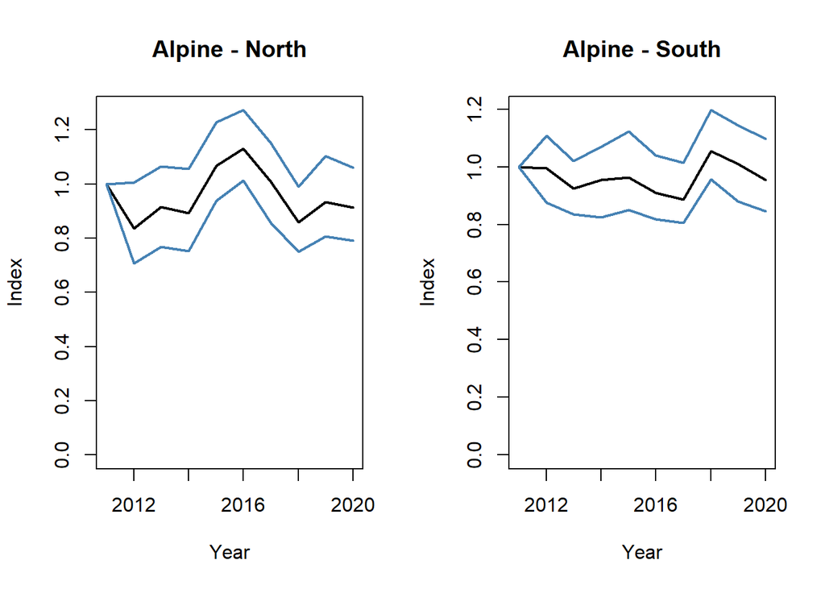

```r
## Plot mean of the sample and their CI
alpa_n_lower = c(1)
alpa_n_upper = c(1)
alpa_s_lower = c(1)
alpa_s_upper = c(1)
for(i in 2:dim(alpa_n_smp)[2]){
  alpa_n_lower = append(alpa_n_lower, quantile(alpa_n_smp[, i], probs = c(0.025, 0.975))[[1]])
  alpa_n_upper = append(alpa_n_upper, quantile(alpa_n_smp[, i], probs = c(0.025, 0.975))[[2]])
  alpa_s_lower = append(alpa_s_lower, quantile(alpa_s_smp[, i], probs = c(0.025, 0.975))[[1]])
  alpa_s_upper = append(alpa_s_upper, quantile(alpa_s_smp[, i], probs = c(0.025, 0.975))[[2]])
}

# North - With CI
par(mfrow = c(1,2))
plot("2011":"2020", colMeans(alpa_n_smp), type = "l", lwd = 2, xlab = "Year", ylab = "Index", ylim = c(0, max(alpa_n_upper)), main = "Alpine - North")
lines("2011":"2020", alpa_n_lower, col = "steelblue", lwd = 2)
lines("2011":"2020", alpa_n_upper, col = "steelblue", lwd = 2)

# South - With CI
plot("2011":"2020", colMeans(alpa_s_smp), type = "l", lwd = 2, xlab = "Year", ylab = "Index", ylim = c(0, max(alpa_s_upper)), main = "Alpine - South")
lines("2011":"2020", alpa_s_lower, col = "steelblue", lwd = 2)
lines("2011":"2020", alpa_s_upper, col = "steelblue", lwd = 2)
```

Compile dataset for the final plot

```r
pdat <- data.frame(year = colnames(alpa_n_smp),
                   med = colMeans(alpa_n_smp),
                   upp = alpa_n_upper,
                   low = alpa_n_lower,
                   reg = "Nord")

pdat2 <- data.frame(year = colnames(alpa_s_smp),
                   med = colMeans(alpa_s_smp),
                   upp = alpa_s_upper,
                   low = alpa_s_lower,
                   reg = "Sør")
pdat <- rbind(pdat, pdat2)
rm(pdat2)
```

```r
regOrder = c("Nord","Sør")
pdat <- pdat[order(match(pdat$reg,regOrder),pdat$year),]
pdat$year <- as.numeric(pdat$year)
```

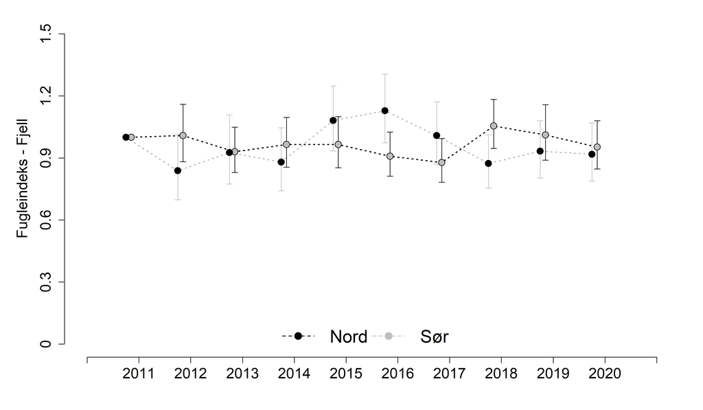

```r
uniq1 <- unique(unlist(pdat$year))
uniq2 <- unique(unlist(pdat$reg))
Nord <- subset(pdat, reg=="Nord")
minyear <- 2010
maxyear <- 2021
lowYlimit <- 0
upperYlimit <- 1.6
move <- 0.1
yStep <- 0.3
colours = c("black", "grey")
legendPosition = "bottom"
legendInset = 0
horizontal = TRUE
legendTextSize = 1.8

png("../output/supplerende indikatorer/fjellfugleindeks.png",
    units="in", width=12, height=7, res=300)

# Plot windows par
par(mfrow=c(1,1), mar=c(4.5,
                        5.5,
                        0,
                        2))

plot(
    Nord$med~Nord$year,
       ylab="Fugleindeks - Fjell",
       xlab="",
       main="",
       xlim=c(minyear, maxyear),
       ylim=c(lowYlimit, upperYlimit),
       cex.main=1,
       cex.lab=1.5,
       cex.axis=1.5,
       type="n",
       frame.plot=FALSE,
       axes=FALSE
    )

  # Axis 1 options
    axis(side=1, at=c(minyear, Nord$year, maxyear), labels=c("",Nord$year, ""), cex.axis=1.5)


  # Axis 2 options
  axis(side=2, at=seq(lowYlimit, upperYlimit, yStep),
       labels=seq(lowYlimit, upperYlimit, yStep),
       cex.axis=1.5)


  # Add lines
  lines(Nord$year+(move*(-2.5)), Nord$med, col=colours[2], lwd=2, lty=3)

  # Save temp points for later addition to plot
  temppoints <- data.frame(year = Nord$year, med = Nord$med)



  for(i in 1:nrow(Nord)){
    arrows(Nord$year[i]+(move*(-2.5)),Nord$med[i],Nord$year[i]+(move*(-2.5)),Nord$upp[i], angle=90, length=0.05, col=colours[2], lwd=1)
    arrows(Nord$year[i]+(move*(-2.5)),Nord$med[i],Nord$year[i]+(move*(-2.5)),Nord$low[i], angle=90, length=0.05, col=colours[2], lwd=1)

  }

  # Empty temporary points data frame
  temppoints3 <- data.frame()




    # Subset for region i
    quants <- subset(pdat, reg==uniq2[2])

    # Add lines
    lines(quants$year+move*(n-2.5), quants$med, col=colours[n], lwd=2, lty=3)

    # Save temp points for later addition to plot
    temppoints2 <- data.frame(year = quants$year, med = quants$med, reg = uniq2[n])
    temppoints3 <- rbind(temppoints3, temppoints2)

    # Add quantiles to plot
    for(i in 1:nrow(quants)){
      arrows(quants$year[i]+move*(n-2.5),quants$med[i],quants$year[i]+move*(n-2.5),quants$upp[i], angle=90, length=0.05, col=colours[n], lwd=1)
      arrows(quants$year[i]+move*(n-2.5),quants$med[i],quants$year[i]+move*(n-2.5),quants$low[i], angle=90, length=0.05, col=colours[n], lwd=1)

  }

  # Add points for regions
  for(n in 1:(length(uniq2)-1)){
    temppoints4 <- temppoints3[temppoints3$reg==uniq2[n],]
    points(temppoints4$year+move*(n-2.5),temppoints4$med, pch=21, bg=colours[2], cex=1.5)
  }

  # Add points for Norge
  points(temppoints$year+(move*(-2.5)),temppoints$med, pch=21, bg=colours[1], cex=1.5)

  # Add legend to plot
  legend(legendPosition, legendPositionY, legend = regOrder, col = colours,
         #bg = c(colours),
         pch=16, lty=2,
         lwd=1.5, bty="n", inset=legendInset, title="", horiz = horizontal,
         cex=legendTextSize)


dev.off()
```